# Explorative Analysis

Patrick Zecchin

# Introduction

Scope of this report is to have a first insight about the downloaded data.

Data were downloaded every day during February 2019 at 23:40 from http://www.viaggiatreno.it/viaggiatrenonew/resteasy/viaggiatreno/*.

```r
# The following libraries will be used:

library(readr)
library(ggplot2)
library(dplyr)
library(tibble)
library(magrittr)
library(knitr)
library(forcats)
library(leaflet)
library(lubridate)
library(igraph)
library(tidygraph)
library(ggraph)
library(tidyr)
```

# Stations

First of all, the list of available train stations and their metadata.

```r
stations <- read_csv("../data/stations.csv", na = "None")
stations %>% head()
```

| id | nomeLungo | nomeBreve | lon | lat | region | codRegion | tipoStazione |
| --- | --- | --- | --- | --- | --- | --- | --- |
| S05700 | ABANO TERME | Abano Terme | 11.811533 | 45.35520 | 12 | NA | 3 |
| S01416 | ABBADIA LARIANA | Abbadia Lariana | 9.335175 | 45.89586 | 1 | NA | 3 |
| S12873 | ABBASANTA | Abbasanta | 8.817733 | 40.12880 | 20 | NA | 3 |
| S01062 | ABBIATEGRASSO | Abbiategrasso | 8.921305 | 45.40063 | 1 | NA | 3 |
| S12409 | ACATE | Acate | 14.425450 | 36.99659 | 14 | NA | 3 |
| S07423 | ACCIANO | Acciano | 13.711345 | 42.17599 | 19 | NA | 3 |

```r
factpal <- colorFactor(rainbow(stations %>% pull(region) %>% unique() %>% length()),
                       stations$region)

leaflet(stations) %>%
  addProviderTiles(providers$ Stamen.TonerLite) %>%
    setView(lng = 12.567380,
            lat = 41.871941,
            zoom = 6) %>%
  addCircleMarkers(
    lat=~lat,
    lng=~lon,
    popup = paste0("<b>STATION DETAILS</b>",
                   "<br/><b>id:</b> ", stations$id,
                   "<br/><b>nomeLungo:</b> ", stations$nomeLungo,
                   "<br/><b>lon:</b> ", stations$lon,
                   "<br/><b>lat:</b> ", stations$lat,
                   "<br/><b>region:</b> ", stations$region,
                   "<br/><b>codRegion:</b> ", stations$codRegion,
                   "<br/><b>tipoStazione:</b> ", stations$tipoStazione),
    label = ~nomeLungo,
    radius = 4,
    stroke = F,
    fillOpacity = 0.8,
    color = ~factpal(region)
  )
```

[interactive chart not shown]

As it is possible to see from the excerpt, the following fields have been made available via API:

- `id`: the unique station identifier
- `nomeLungo` and `nomeBreve`: the station common name
- `lon` and `lat`: geographical coordinates
- `region`: the region of the station (available for 2464 rows, 86.2443122% of the total)
- `codRegion`: always not available
- `tipoStazione`: not clear.

The following plot shows the distribution of stations by region. Please note that:

- some regions are clearly identifiable (e.g. `3` corresponds to Piedmont, `4` to Aosta Valley)
- Trentino-Alto Adige/Südtirol seems to be splitted in three (`9`, `21`, `22`)
- `NA` is unfortunately the most common region code, followd by `3` (Piedmont) and `1` (Lombardy).

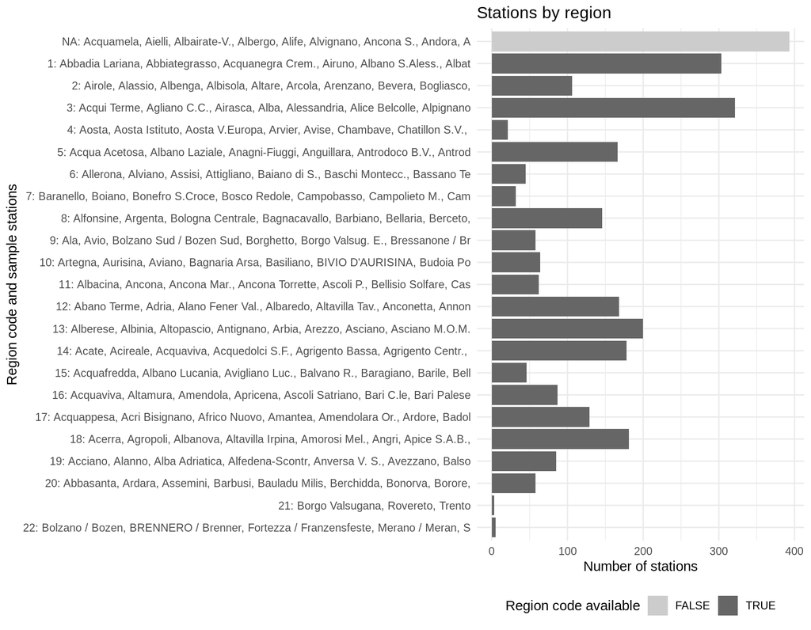

```r
stations %>%
  group_by(region) %>%
  summarise(count = n(),
            stations = paste(nomeBreve, collapse = ", ")) %>%
  mutate(stations = paste0(region, ": ", substr(stations, 1, 80))) %>%
  ggplot(aes(fct_reorder(stations, -region), count)) +
  geom_col(aes(fill=!is.na(region))) +
  xlab("Region code and sample stations") +
  ylab("Number of stations") +
  ggtitle("Stations by region") +
  scale_fill_grey("Region code available", start=0.8, end=0.4) +
  coord_flip() +
  theme_minimal() +
  theme(legend.position = "bottom")
```

# Train trips (aggregated)

The second dataset is one row per train trip. More in details, it is possible to find:

- `train_number`: the train identifier
- `trip_date`
- `category`: the train level of service
- `origin` and `origin_id`
- `destination` and `destination_id`
- `num_stops` and `num_deleted_stops`: the number of stops, expected and deleted.

```r
aggr <- list.files(path="../data/train_status", pattern="*.csv") %>%
  paste0("../data/train_status/", .) %>%
  lapply(., function(x) read.csv(x, stringsAsFactors = FALSE)) %>%
  do.call(rbind, .) %>%
  mutate(trip_date = as.Date(trip_date))

aggr %>% head()
```

|  | train_number | trip_date | train_type | category | origin_id | origin | destination_id | destination | num_stops | num_deleted_stops |
| --- | --- | --- | --- | --- | --- | --- | --- | --- | --- | --- |
| 1 | 10 | 2019-02-01 | PG | EC | S02593 | VENEZIA SANTA LUCIA | S01301 | CHIASSO | 10 | 0 |
| 2 | 11 | 2019-02-01 | PG | EC | S01301 | CHIASSO | S01700 | MILANO CENTRALE | 3 | 0 |
| 3 | 12 | 2019-02-01 | PG | EC | S01700 | MILANO CENTRALE | S01301 | CHIASSO | 3 | 0 |
| 4 | 13 | 2019-02-01 | PG | EC | S01301 | CHIASSO | S01700 | MILANO CENTRALE | 4 | 0 |
| 5 | 13 | 2019-02-01 | PG | REG | N00001 | M N CADORNA | N00033 | LAVENO | 24 | 0 |
| 6 | 14 | 2019-02-01 | PG | EC | S01700 | MILANO CENTRALE | S01301 | CHIASSO | 4 | 0 |

Please note that `train_number` unfortunately is not a true identifier. Consider for example `trip_date: 2019-02-01`, the following (sampled) train ids appear more than once.

```r
aggr %>%
  filter(trip_date=="2019-02-01") %>%
  group_by(train_number) %>%
  summarise(count = n()) %>%
  arrange(desc(count)) %>%
  head(5)
```

| train_number | count |
| --- | --- |
| 8583 | 4 |
| 8587 | 4 |
| 26618 | 4 |
| 141 | 3 |
| 145 | 3 |

I checked manually on the online portal for some of these and, for example:

- `ES 8583` starts from Genova Principe and becomes `8584` in Pisa Centrale, `8585` in Firenze Rifredi and `8586` in Roma Tiburtina
- `ES 8587` is the same as `8583`, on the way back
- `REG 26618` starts from Agrigento Centrale and becomes `26617` in Lercara, `26616` in Roccapalumba-Alia and `26619` in Caltanissetta Xirbi.

However, this phenomenon seems to be not too widespread.

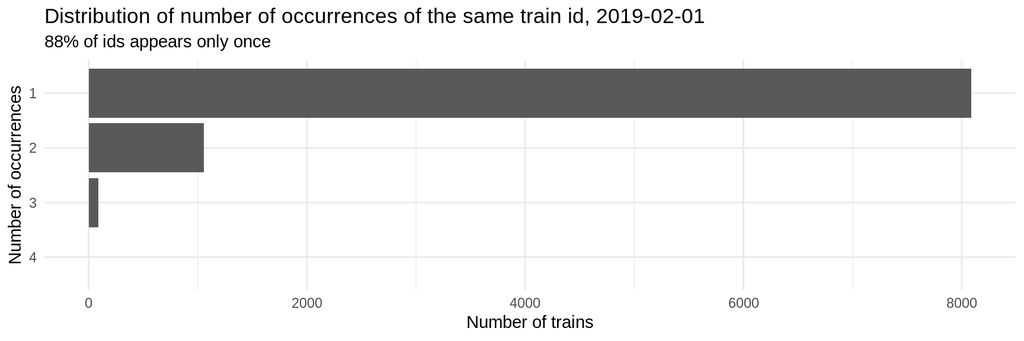

```r
temp <- aggr %>%
  filter(trip_date=="2019-02-01") %>%
  group_by(train_number) %>%
  summarise(count = n()) %>%
  group_by(count) %>%
  summarise(num_occ = n()) %>%
   mutate(perc=num_occ/sum(num_occ))

temp %>%
  ggplot(aes(fct_reorder(as.factor(count), num_occ), num_occ)) +
  geom_col() +
  labs(x = "Number of occurrences",
       y = "Number of trains",
       title = "Distribution of number of occurrences of the same train id, 2019-02-01",
       subtitle = paste0(temp %>% filter(count==1) %>% pull(perc) %>% `*`(100) %>% round(), "% of ids appears only once")) +
  coord_flip() +
  theme_minimal()
```

The following plot shows how many trains the system recorded during each day. A couple of annotations have to be made here:

- due to some technical inconvenience, Saturday 23rd and Sunday 24th February were not recorded. Since the final scope of the analysis does not include an historical/trend analysis of these data, the missing days have been replaced by Saturday 2nd and Sunday 10th March.
- something (unknown) happened during Tuesday 19th February, when only ~4K ids were downloaded (a “tipical” Tuesday has ~10K ids). Unfortunately, it’s not clear where the issue was originated.

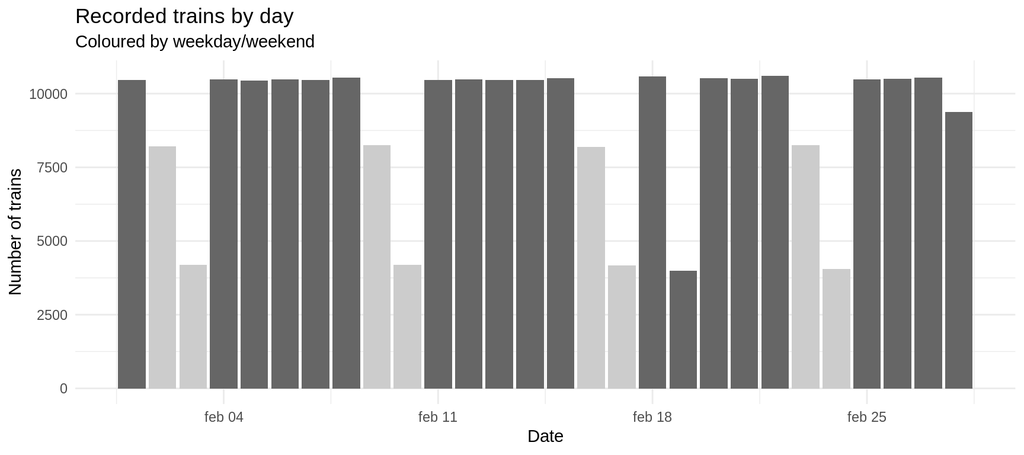

```r
aggr %>%
  mutate(dow = weekdays(trip_date, T), dow = ifelse(dow %in% c("sab", "dom"), TRUE, FALSE)) %>%
  ggplot() +
  geom_bar(aes(trip_date, fill=dow)) +
  scale_fill_grey(start=0.4, end=0.8) +
  labs(title = "Recorded trains by day",
       subtitle = "Coloured by weekday/weekend",
       x = "Date",
       y = "Number of trains") +
  theme_minimal() +
  theme(legend.position = "None")
```

The next plots show, respectively, the distribution of the train level of service, of the number of stops and of the starting station.

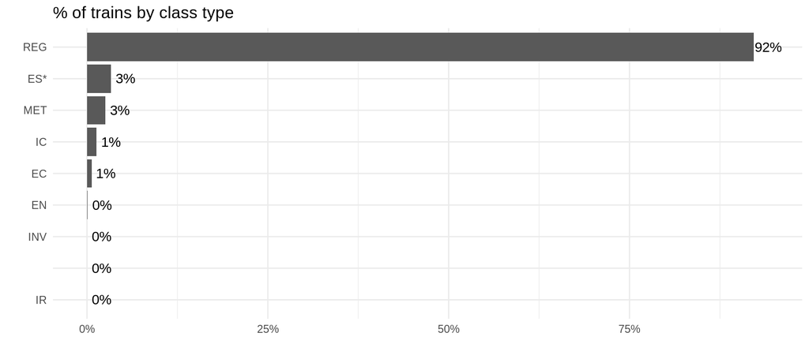

```r
aggr %>%
  group_by(category) %>%
  summarise(count = n()) %>%
  mutate(count = count/sum(count)) %>%
  ggplot(aes(x=fct_reorder(category, count), y=count)) +
  geom_col() +
  geom_text(aes(y = count + 0.02, label = paste0(round(100*count), "%"))) +
  xlab("") +
  ylab(("")) +
  ggtitle("% of trains by class type") +
  scale_y_continuous(labels = scales::percent_format(accuracy = 1)) +
  coord_flip() +
  theme_minimal()
```

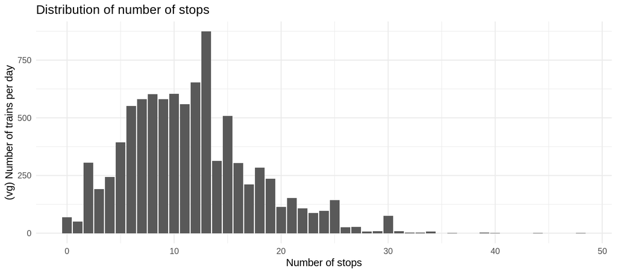

```r
ndays <- aggr %>% pull(trip_date) %>% n_distinct()

aggr %>%
  group_by(num_stops) %>%
  summarise(count = n()/ndays) %>%
  ggplot(aes(x=num_stops, y=count)) +
  geom_col() +
  xlab("Number of stops") +
  ylab("(vg) Number of trains per day") +
  ggtitle("Distribution of number of stops") +
  theme_minimal()
```

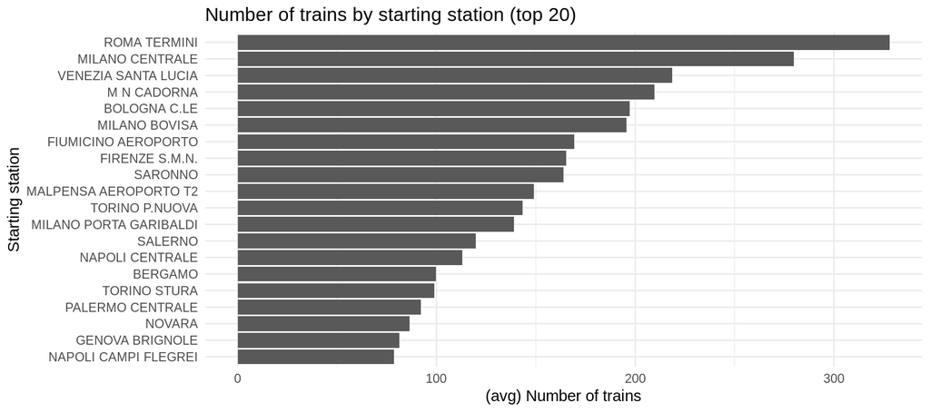

```r
aggr %>%
  group_by(origin) %>%
  summarise(count = n()/ndays) %>%
  arrange(desc(count)) %>%
  head(20) %>%
  ggplot() +
  geom_bar(aes(x=fct_reorder(origin,count), y=count), stat = "identity") +
  ylab("(avg) Number of trains") +
  xlab("Starting station") +
  ggtitle("Number of trains by starting station (top 20)") +
  coord_flip() +
  theme_minimal()
```

# Single trains

The last dataset contains one row for each “segment” of trip.

```r
raw_data <- list.files(path="../data/single_train_status", pattern="*.csv") %>%
  paste0("../data/single_train_status/", .) %>%
  lapply(., function(x) read.csv(x, stringsAsFactors = FALSE)) %>%
  do.call(rbind, .) %>%
  mutate(trip_date = as.Date(trip_date),
         from_planned = as_datetime(from_planned, tz="Europe/Rome"),
         from_real = as_datetime(from_real, tz="Europe/Rome"),
         to_planned = as_datetime(to_planned, tz="Europe/Rome"),
         to_real = as_datetime(to_real, tz="Europe/Rome"),
         inc_delay = as.numeric(inc_delay)/60,
         seg_delay = as.numeric(seg_delay)/60,
         fin_delay = as.numeric(fin_delay)/60)

raw_data %>% head()
```

|  | train_number | trip_date | step | from_id | from_planned | from_real | to_id | to_planned | to_real | inc_delay | seg_delay | fin_delay |
| --- | --- | --- | --- | --- | --- | --- | --- | --- | --- | --- | --- | --- |
| 1 | 10 | 2019-02-01 | 0 | S02593 |  |  | S02593 | 2019-02-01 15:20:00 | 2019-02-01 15:22:00 | NA | NA | 2.0 |
| 2 | 10 | 2019-02-01 | 1 | S02593 | 2019-02-01 15:20:00 | 2019-02-01 15:22:00 | S02589 | 2019-02-01 15:30:00 | 2019-02-01 15:33:00 | 2.0 | 1.0 | 3.0 |
| 3 | 10 | 2019-02-01 | 2 | S02589 | 2019-02-01 15:30:00 | 2019-02-01 15:33:00 | S02589 | 2019-02-01 15:32:00 | 2019-02-01 15:35:30 | 3.0 | 0.5 | 3.5 |
| 4 | 10 | 2019-02-01 | 3 | S02589 | 2019-02-01 15:32:00 | 2019-02-01 15:35:30 | S02581 | 2019-02-01 15:46:00 | 2019-02-01 15:47:00 | 3.5 | -2.5 | 1.0 |
| 5 | 10 | 2019-02-01 | 4 | S02581 | 2019-02-01 15:46:00 | 2019-02-01 15:47:00 | S02581 | 2019-02-01 15:48:00 | 2019-02-01 15:49:30 | 1.0 | 0.5 | 1.5 |
| 6 | 10 | 2019-02-01 | 5 | S02581 | 2019-02-01 15:48:00 | 2019-02-01 15:49:30 | S02446 | 2019-02-01 16:03:00 | 2019-02-01 16:03:00 | 1.5 | -1.5 | 0.0 |

The available fields are the following:

- `train_number`: the train identifier, as seen above
- `trip_date`: the date the files was downloaded, that is the date of the trip
- `step`: the incremental segment identifier
- `from_id`, `from_planned`, `from_real`: starting station id, planned departure time and real departure time
- `to_id`, `to_planned`, `to_real`: destination station id, planned arrival time and real arrival time
- `inc_delay`, `seg_delay`, `fin_delay`: delay (in minutes) gained before the segment, during the segment and at the end of it.

Incoming, segment and final delay are computed as follows:
$$inc\_delay = from\_real-from\_planned$$
$$fin\_delay = to\_real-to\_planned$$
$$seg\_delay = fin\_delay-inc\_delay.$$

The following picture may help understand the data model and the meaning of the `step` variable. Consider for example train `10`:

0. at step `0`, it starts at Venezia S.Lucia (`S02593`) with 2 min delay
1. at step `1`, it moves from Venezia S.Lucia to Venezia Mestre (`S02589`); its delay is 2 mins (from step `0`) plus 1 min
2. at step `2`, it stays in Venezia Mestre (that is, it “starts” rom Venezia Mestre and it arrives in Venezia Mestre), with a incoming delay of 3 mins and gaining 0.5 min of delay in the station stop
3. at step `3`, it moves from Venezia Mestre to Padova (`S02581`), starting with 3.5 mins of delay and arriving just 1 min late (that is, recovering 2.5 mins)
4. etc.

This data model should make it easier to check the train delays and where they are originated.

```r
temp <- raw_data %>%
  filter(train_number==10, trip_date=="2019-02-01") %>%
    left_join(., stations %>% select(id, nomeBreve), by=c("from_id"="id")) %>%
  rename("from"="nomeBreve") %>%
  left_join(., stations %>% select(id, nomeBreve), by=c("to_id"="id")) %>%
  rename("to"="nomeBreve")

temp
```

| train_number | trip_date | step | from_id | from_planned | from_real | to_id | to_planned | to_real | inc_delay | seg_delay | fin_delay | from | to |
| --- | --- | --- | --- | --- | --- | --- | --- | --- | --- | --- | --- | --- | --- |
| 10 | 2019-02-01 | 0 | S02593 |  |  | S02593 | 2019-02-01 15:20:00 | 2019-02-01 15:22:00 | NA | NA | 2.0 | Venezia S.Lucia | Venezia S.Lucia |
| 10 | 2019-02-01 | 1 | S02593 | 2019-02-01 15:20:00 | 2019-02-01 15:22:00 | S02589 | 2019-02-01 15:30:00 | 2019-02-01 15:33:00 | 2.0 | 1.0 | 3.0 | Venezia S.Lucia | Venezia Mestre |
| 10 | 2019-02-01 | 2 | S02589 | 2019-02-01 15:30:00 | 2019-02-01 15:33:00 | S02589 | 2019-02-01 15:32:00 | 2019-02-01 15:35:30 | 3.0 | 0.5 | 3.5 | Venezia Mestre | Venezia Mestre |
| 10 | 2019-02-01 | 3 | S02589 | 2019-02-01 15:32:00 | 2019-02-01 15:35:30 | S02581 | 2019-02-01 15:46:00 | 2019-02-01 15:47:00 | 3.5 | -2.5 | 1.0 | Venezia Mestre | Padova |
| 10 | 2019-02-01 | 4 | S02581 | 2019-02-01 15:46:00 | 2019-02-01 15:47:00 | S02581 | 2019-02-01 15:48:00 | 2019-02-01 15:49:30 | 1.0 | 0.5 | 1.5 | Padova | Padova |
| 10 | 2019-02-01 | 5 | S02581 | 2019-02-01 15:48:00 | 2019-02-01 15:49:30 | S02446 | 2019-02-01 16:03:00 | 2019-02-01 16:03:00 | 1.5 | -1.5 | 0.0 | Padova | Vicenza |
| 10 | 2019-02-01 | 6 | S02446 | 2019-02-01 16:03:00 | 2019-02-01 16:03:00 | S02446 | 2019-02-01 16:05:00 | 2019-02-01 16:06:00 | 0.0 | 1.0 | 1.0 | Vicenza | Vicenza |
| 10 | 2019-02-01 | 7 | S02446 | 2019-02-01 16:05:00 | 2019-02-01 16:06:00 | S02430 | 2019-02-01 16:30:00 | 2019-02-01 16:36:30 | 1.0 | 5.5 | 6.5 | Vicenza | Verona P.Nuova |
| 10 | 2019-02-01 | 8 | S02430 | 2019-02-01 16:30:00 | 2019-02-01 16:36:30 | S02430 | 2019-02-01 16:32:00 | 2019-02-01 16:39:30 | 6.5 | 1.0 | 7.5 | Verona P.Nuova | Verona P.Nuova |
| 10 | 2019-02-01 | 9 | S02430 | 2019-02-01 16:32:00 | 2019-02-01 16:39:30 | S02088 | 2019-02-01 16:46:00 | 2019-02-01 16:50:30 | 7.5 | -3.0 | 4.5 | Verona P.Nuova | Peschiera Garda |

[output cut: 8 more lines]

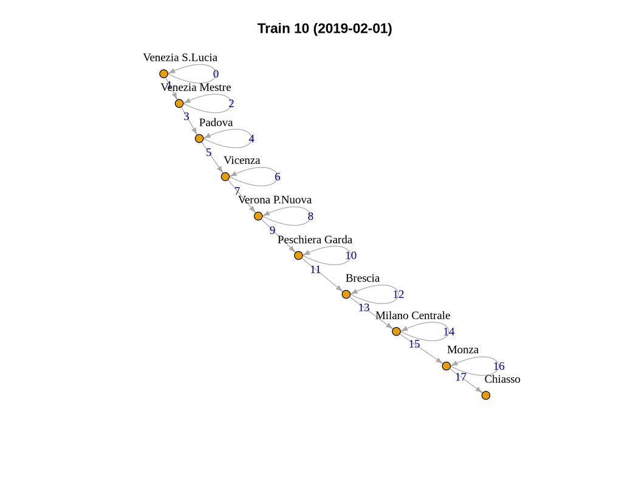

```r
routes_tidy <- tbl_graph(nodes = stations %>%
                           filter(nomeBreve %in% c(temp$from, temp$to)) %>%
                           select(nomeBreve) %>%
                           rename(name=nomeBreve),
                         edges = temp %>% select(from, to),
                         directed = TRUE)
plot(routes_tidy,
     edge.arrow.size=.5,
     vertex.size=5,
     vertex.frame.color="black",
     vertex.label.color="black",
     vertex.label.cex=1,
     vertex.label.dist=2,
     edge.curved=0,
     edge.label=temp$step,
     main="Train 10 (2019-02-01)")
```

The next plot shows the number of data points available by time (`from_planned`). It is possible to point out the same notes highlighted above, that are the data about Saturday 23rd and Sunday 24th February and the issue during Tuesday 19th.

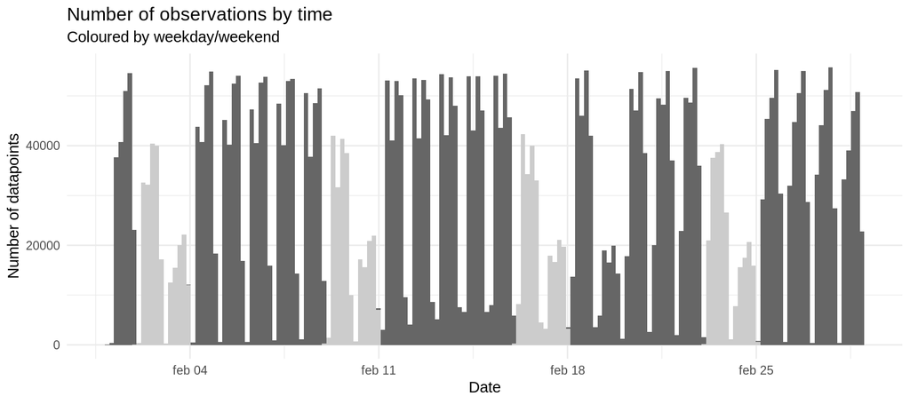

```r
raw_data %>%
  mutate(dow = weekdays(trip_date, T), dow = ifelse(dow %in% c("sab", "dom"), TRUE, FALSE)) %>%
  ggplot(aes(x=from_planned, fill=dow)) +
  geom_histogram(bins = ndays*6) +
  scale_fill_grey(start=0.4, end=0.8) +
  labs(title = "Number of observations by time",
       subtitle = "Coloured by weekday/weekend",
       x = "Date",
       y = "Number of datapoints") +
  theme_minimal() +
  theme(legend.position = "None")
```

The number of data points per hour of day highlights the same pattern shown in the previous plot, with a peak during the morning commute hour and a second height during the afternoon.

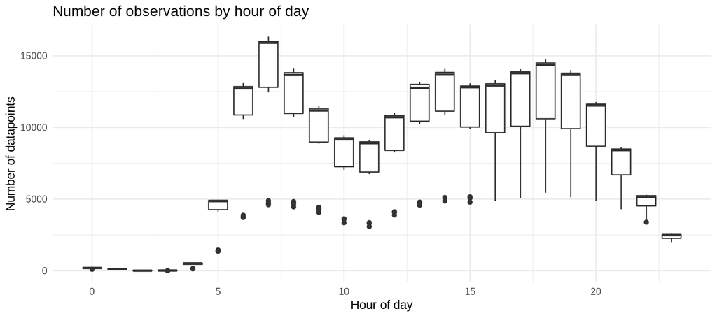

```r
raw_data %>%
  filter(!is.na(from_planned), trip_date != "2019-02-19") %>%
  mutate(hour = hour(from_planned)) %>%
  group_by(hour, trip_date) %>%
  summarise(count=n()) %>%
  ggplot() +
  geom_boxplot(aes(x=hour, group=hour, y=count)) +
  xlab("Hour of day") +
  ylab("Number of datapoints") +
  ggtitle("Number of observations by hour of day") +
  theme_minimal()
```

For what concerns data availability, the next table presents the number of observation by available feature. More in detail

- about 70% of the data contains all the four timestamps
- 10% does not have neither `from_real` nor `to_real`
- 7% does not have `from_real` and another 7% `to_real`.

```r
raw_data %>%
  select(from_planned, from_real, to_planned, to_real) %>%
  mutate(from_planned = !is.na(from_planned),
         from_real = !is.na(from_real),
         to_planned = !is.na(to_planned),
         to_real = !is.na(to_real)) %>%
  group_by(from_planned, from_real, to_planned, to_real) %>%
  summarise(count = n()) %>%
  ungroup() %>%
  mutate(perc = round(count/sum(count),3))
```

| from_planned | from_real | to_planned | to_real | count | perc |
| --- | --- | --- | --- | --- | --- |
| FALSE | FALSE | FALSE | FALSE | 27500 | 0.005 |
| FALSE | FALSE | FALSE | TRUE | 355 | 0.000 |
| FALSE | FALSE | TRUE | FALSE | 15925 | 0.003 |
| FALSE | FALSE | TRUE | TRUE | 229496 | 0.043 |
| FALSE | TRUE | FALSE | FALSE | 35 | 0.000 |
| FALSE | TRUE | FALSE | TRUE | 96 | 0.000 |
| FALSE | TRUE | TRUE | FALSE | 480 | 0.000 |
| FALSE | TRUE | TRUE | TRUE | 6194 | 0.001 |
| TRUE | FALSE | FALSE | FALSE | 3339 | 0.001 |
| TRUE | FALSE | FALSE | TRUE | 243 | 0.000 |

[output cut: 6 more lines]